# Analysis of Pharmaceutical Drug Spending in NAFTA Countries

Grayson Shanley Barr and Asha Kannan

```r
library(tidyverse)
library(kableExtra)
library(readr)
library(janitor)
```

```r
#Import the Data
drug_spending <- read.csv("drug_spending.csv")

# Data Cleaning
clean_data <- distinct(drug_spending) # only keeps distinct entries
clean_data <- clean_names(drug_spending) # cleans header names

# Subset data for NAFTA Countries
NAFTA <- clean_data %>%
  filter(location =="USA" | location == "MEX" | location == "CAN")

NAFTA_2014 <- NAFTA %>%
  filter(time ==2014)
```

# Introduction

Over the last 50 years, pharmaceutical drug spending has risen at drastic rates, and is particularly evident in the United States. For example, in 2021 the US reported 378 billion dollars in prescription drug expenditure. Furthermore, it is thought provoking to examine how pharmaceutical drug spending has varied over time and how spending levels differ among countries with varying approaches to healthcare.

This analysis examines a dataset concerning pharmaceutical spending compiled by the Organization for Economic Co-operation and Development (OECD), an intergovernmental organization that exists in 38 countries. In spring 2018, the OECD compiled a survey to collect data on pharmaceutical expenditures and initially received responses from twenty two countries. The survey aimed to determine how each country monitored its own pharmaceutical data—most of which appeared to be collected through reimbursement claims from patients and pharmacies. In order to predict future pharmaceutical budgets for such countries, the OECD has used the information reported directly by countries, as well as studies conducted by national agencies and universities.

The total funding is represented as a percentage of the total GDP for each country, percent per capita in USD, percent of total GDP by country, and percent of total healthcare expenditure. The indices that are normalized per capita are a helpful analysis tool since countries with higher populations are likely to spend more money on pharmaceuticals per year when comparing total pharmaceutical spending.

The main focus of our report will be the economic relationship between the NAFTA countries—the United States, Canada, and Mexico—with specific focus on the changing percent GDP and percent healthcare expenditure over time of these countries.

The North American Free Trade Agreement (NAFTA) was implemented in 1994 to encourage trade between the countries of the United States, Mexico, and Canada. NAFTA created a large free-trade zone reducing or eliminating tariffs on imports and exports between the three participating countries (the U.S, Mexico, and Canada). Since the implementation of NAFTA, there has been an increase in trade between the three countries, and real per-capita GDP has also increased slightly.

It is particularly interesting to examine the three countries engaged in NAFTA, given their proximate geographic locations and their vastly different approaches to healthcare. For example, Canada has a decentralized, universal and publicly funded health system called Canadian Medicare. In Canada, healthcare is funded and administered primarily by the country’s 13 provinces and territories. Each province has its own insurance plan, and each receives cash assistance from the federal government on a per-capita basis. Meanwhile, the healthcare system in the United States does not provide universal coverage and can be defined as a mixed system, where publicly financed government Medicare and Medicaid health coverage coexists with privately financed private health insurance plans. Finally, Mexico has a fragmented healthcare system with three main types of service providers; the Mexican Institute of Social Security (IMSS) provides coverage for private-sector employees and their families, a second form of healthcare comes from private service providers and insurance companies, and a third provider is through safety net social programs funded by the government. Furthermore, these differences in approaches to funding healthcare may be reflected in the percent healthcare expenditures, and percent of the GDP each of these countries invests in their respective healthcare systems.

Prior to our analysis, we hypothesized that larger countries would have higher total spending rates on pharmaceuticals, and countries that are more economically developed would have high rates of pharmaceutical spending. In regard to NAFTA participating countries, we posit that the United States will have the highest GDP per capita and percent GDP in pharmaceutical drug spending, given the country’s history of high rates of healthcare spending.

# Results

The results show that United States spent the most amount of money on pharmaceutical drugs in 2014, whereas Mexico spent the least.

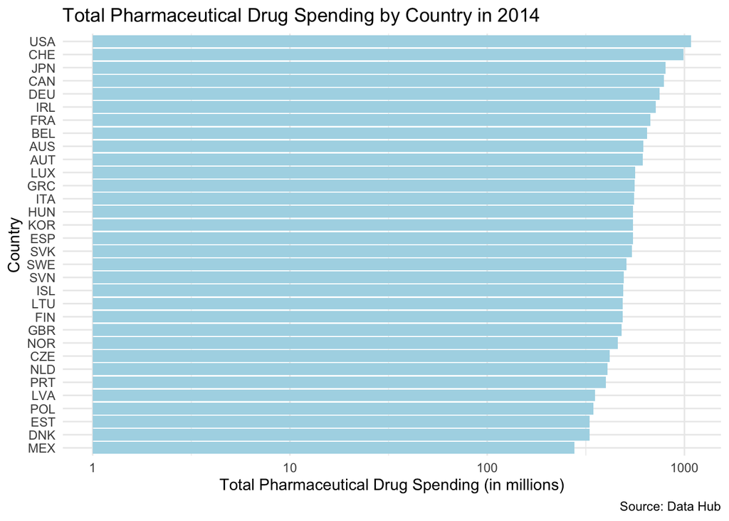

```r
# Bar graph of USD Capita over time

data_2014 <- clean_data %>%
    filter(time == 2014)

data_2014 %>%
  arrange(by=-usd_cap) %>%
  ggplot(aes(x=usd_cap, y=reorder(location,usd_cap)))+
  geom_bar(stat = "identity", fill="lightblue")+
  xlab("Total Pharmaceutical Drug Spending (in millions)") +
  ylab("Country") +
  ggtitle("Total Pharmaceutical Drug Spending by Country in 2014") +
  scale_x_log10()+
  theme_minimal()+
  labs(caption = "Source: Data Hub")
```

While the United States has the highest GDP per capita and percent GDP, its percent healthcare expenditure is the lowest. On the other hand, while Mexico has the lowest GDP per capita (USD) and lowest percent GDP, it also has the highest percent healthcare expenditure.

**Table 1:** Table of the GDP per capita (in USD), percent GDP, and percent healthcare expenditure for the NAFTA countries in the year 2014.

```r
# NAFTA Table
NAFTA_2014 %>%
  arrange(-usd_cap) %>%
  select(location, usd_cap, pc_gdp, pc_healthxp) %>%
  mutate(usd_cap = round(usd_cap, digits = 2),
         pc_gdp =round(pc_gdp, digits =2),
         pc_healthxp =round(pc_healthxp, digits = 2)) %>%
  kbl(col.names = c("Country", "Per Capita USD", "Percent GDP", "Percent Healthcare Expenditure" ),
    caption = "Pharmaceutical Spending for NAFTA Countries in 2014",
    align="ll") %>%
  kable_styling(font_size = 14) %>% #kabel styling to specify that it is a number
  kable_minimal() %>%
  row_spec(1, bold=T) %>%
  row_spec(2, bold=T) %>%
  row_spec(3, bold=T) %>%
  row_spec(1, color = "#0D638F") %>%
  row_spec(2, color = "#DC582A") %>%
  row_spec(3, color = "darkgreen") %>%
  footnote(general = "Source: Data Hub")
```

Pharmaceutical Spending for NAFTA Countries in 2014

| Country | Per Capita USD | Percent GDP | Percent Healthcare Expenditure |
| --- | --- | --- | --- |
| USA | 1081.40 | 1.98 | 11.97 |
| CAN | 785.81 | 1.74 | 17.45 |
| MEX | 277.23 | 1.54 | 27.01 |

Note:  
Source: Data Hub

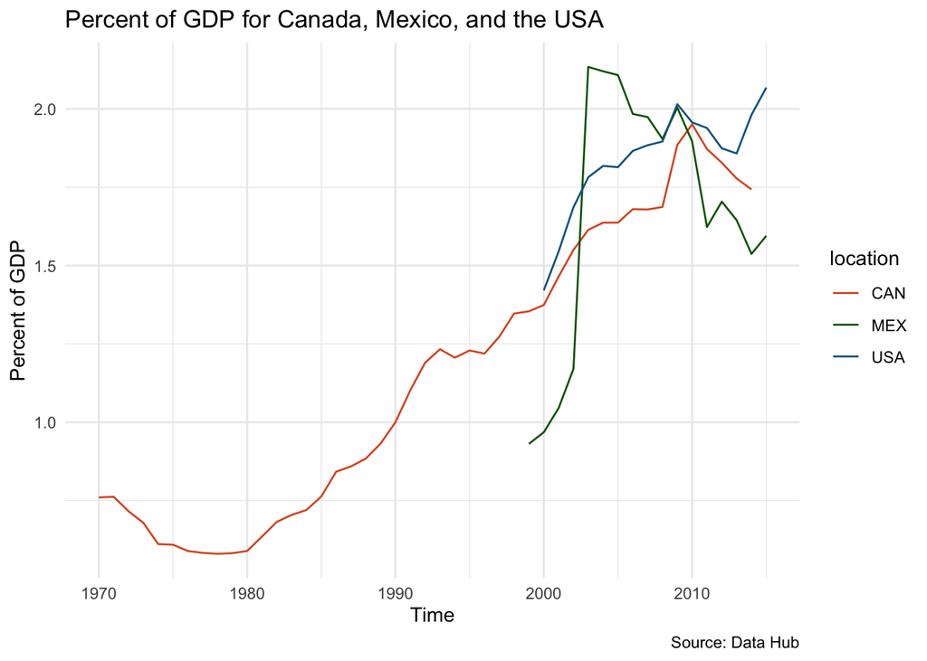

```r
# This is for Percent per capita GDP:

clean_data %>%
  filter(location == "USA"| location == "MEX"| location == "CAN") %>%
  ggplot(aes(x=time, y=pc_gdp, group=location, color=location)) +
  geom_line() +
  scale_color_manual(values=c("#DC582A", "darkgreen", "#0D638F")) +
  xlab("Time") +
  ylab("Percent of GDP") +
  ggtitle("Percent of GDP for Canada, Mexico, and the USA") +
  theme_minimal()+
  labs(caption = "Source: Data Hub")
```

**Figure 2:** Line graph of the percentage of GDP for NAFTA countries over time.

Mexico has consistently spent more of their pharmaceutical budget on healthcare than Canada and the United States. While Mexico has experienced more drastic changes to their percentage of healthcare expenditure over time, the United States’s spending has stayed relatively constant over time, and Canada’s spending has increased steadily from 1980.

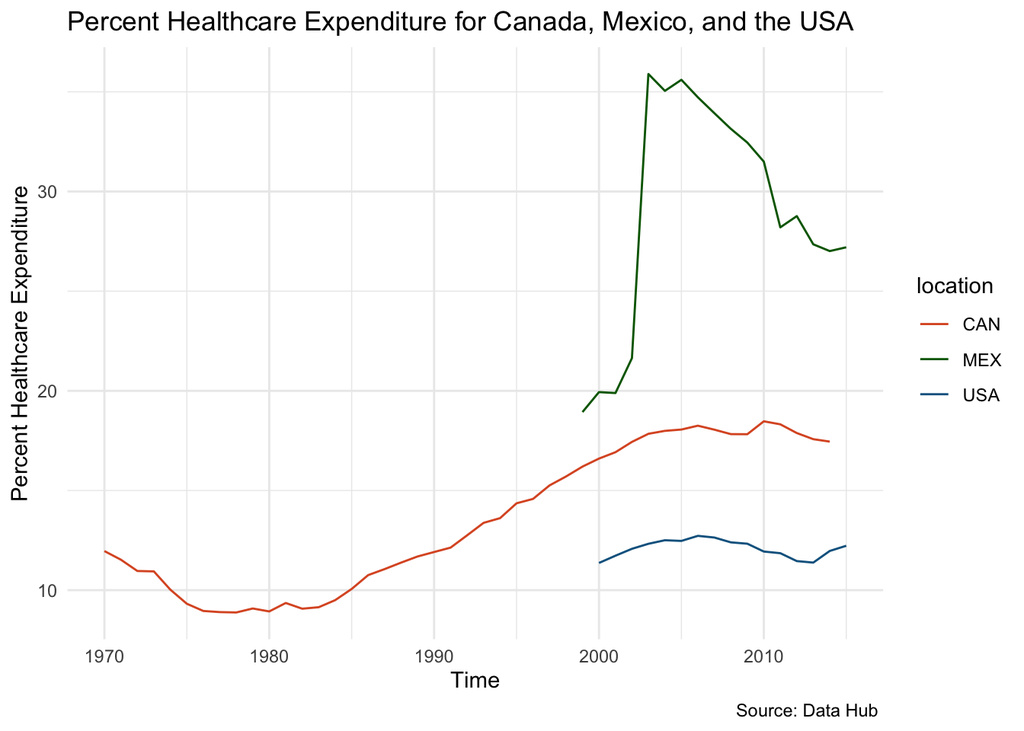

```r
# This is for percent healthcare expenditures (USD):
clean_data %>%
  filter(location == "USA"| location == "MEX"| location == "CAN") %>%
  ggplot(aes(x=time, y=pc_healthxp, group=location, color=location)) +
  geom_line() +
  scale_color_manual(values=c("#DC582A", "darkgreen", "#0D638F")) +
  xlab("Time") +
  ylab("Percent Healthcare Expenditure") +
  ggtitle("Percent Healthcare Expenditure for Canada, Mexico, and the USA") +
  theme_minimal()+
  labs(caption = "Source: Data Hub ")
```

**Figure 3:** Line graph of the percentage of healthcare spending for NAFTA countries.

Figure 3 shows how Mexico has consistently had higher rates of of pharmaceutical helth care spending since 2000.

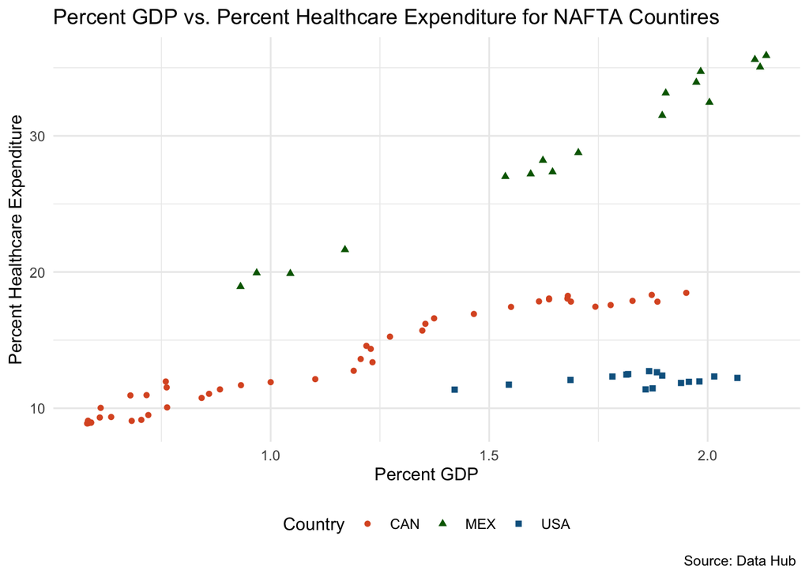

```r
# NAFTA Scatterplot
NAFTA %>%
  ggplot(aes(x=pc_gdp, y=pc_healthxp))+
  geom_point(aes(col=location, pch=location))+
  scale_color_manual(values=c("#DC582A", "darkgreen", "#0D638F"))+
  xlab("Percent GDP") +
  ylab("Percent Healthcare Expenditure") +
  ggtitle("Percent GDP vs. Percent Healthcare Expenditure for NAFTA Countires") +
  theme_minimal()+
  theme(legend.position = "bottom")+
  labs(color="Country", pch="Country")+
  labs(caption = "Source: Data Hub ")
```

**Figure 4:** Scatterplot of percent health care spending vs. percent GDP allocated for pharmaceutical spending in NAFTA countries.

Figure 4 shows a positive association between the percent of healthcare spending and percent of GDP for the NAFTA countries. As the percent GDP increases, the percent of healthcare spending also increases.

# Discussion

After plotting the first graph—which summarizes the total spending on pharmaceutical drugs in all of the surveyed questions in 2014—it was clear that the initial assumption in which countries with larger populations would also have spent more money each year was not necessarily true. While this hypothesis was maintained for the United States, Switzerland (with a population of ~8 million people) had the next highest spending in 2014. One potential explanation is that much of Switzerland’s pharmaceutical spending is financed by public spending, and in recent years the number of drugs that are covered by health insurance has also increased which has likely contributed to increases in total drug spending.

Table 1, Figure 2, and Figure 3 affirmed the hypotheses that we originally proposed, showing that the United States had the highest GDP per capita and percent GDP, and Mexico had the lowest value in both categories. However, the United States has the lowest percent healthcare expenditure, whereas Mexico has the highest percentage. This difference could be due to the privatized healthcare system in the United States, in contrast to the publicly funded healthcare in Canada and the social safety net programs in Mexico.

One limitation of the analysis is that the dataset does not include data points for every year from 1970-2015 for all three NAFTA countries. Mexico and the United States, particularly, lacked data from before 1999 and 2000, respectively. This lack of data made it difficult to see long-term trends that might impact future pharmaceutical spending, percent GDP, or percent healthcare expenditures.

# Author Contributions

# References

Commonwealth Fund: Canada. (2020). International Health Care System Profiles. https://www.commonwealthfund.org/international-health-policy-center/countries/canada. Accessed March 14th, 2023.

[Data Hub](https://datahub.io/core/pharmaceutical-drug-spending/r/0.html)

Data Hub. (2023). Pharmaceutical Drug Spending by Country. [Dataset]. https://datahub.io/core/pharmaceutical-drug-spending. Accessed March 10th, 2023.

Floyd, D. (2023). How did NAFTA Affect the Economies of Participating Countries? Investopedia. https://www.investopedia.com/articles/economics/08/north-american-free-trade-agreement.asp

Frenk, J., Gómez-Dantés, O., Cruz, C., Chacón, F., Hernández, P., & Freeman, P. (1994). Consequences of the North American Free Trade Agreement for health services: a perspective from Mexico. American journal of public health, 84(10), 1591–1597. https://doi.org/10.2105/ajph.84.10.1591

ISPOR. (2023). US Healthcare System Overview. https://www.ispor.org/heor-resources/more-heor-resources/us-healthcare-system-overview/us-healthcare-system-overview-background-page-1. Accessed March 14th, 2023.

OECD (2023), Pharmaceutical spending (indicator). doi: 10.1787/998febf6-en (Accessed on 14 March 2023). https://data.oecd.org/healthres/pharmaceutical-spending.htm#indicator-chart

OECD (2023), “Health expenditure and financing: Health expenditure indicators”, OECD Health Statistics (database), https://doi.org/10.1787/data-00349-en (accessed on 14 March 2023).

Organisation for Economic Co-Operation and Development (OECD). (2019). Improving Forecasting of Pharmaceutical Spending—Insights from 23 OECD and EU Countries. https://www.oecd.org/health/health-systems/Improving-Forecasting-of-Pharmaceutical-Spending-Report.pdf